# Generate peptide and adjusted SWISSPROT sequences

Mario Keller

Faculty of Biological Sciences, Goethe University Frankfurt

2 May 2023

```r
library(tidyverse)
library(knitr)
library(ggpubr)
library(ggsci)
library(ggpointdensity)
library(viridis)
library(patchwork)
library(GenomicRanges)
library(ggbeeswarm)
library(rtracklayer)
library(plyranges)
library(BSgenome.Hsapiens.UCSC.hg38)
library(Biostrings)
```

```r
myTheme <- theme_bw() +
    theme(axis.text = element_text(size = 14, colour="black"),
          axis.title = element_text(size=16, colour="black"),
          axis.ticks=element_line(color="black"),
          axis.ticks.length=unit(.15, "cm"),
          panel.border=element_rect(color="black", fill = NA),
          panel.background = element_blank(),
          plot.background = element_blank(),
          legend.text = element_text(size=12),
          legend.position = "none")
```

# 1 Background

Based on the A5SS events responsive to USP39 knockdown SWISS-PROT sequences should be adjusted.

# 2 Data

A GRangesList comprising the A5SS events is loaded from ab RDS-File.

```r
A5SSranges <- readRDS("rds_files/A5SSranges.rds")
```

In addition, I the Gencode v38 annotation is loaded and and all CDS exons extracted.

```r
anno <- import("data/gencode.v38.annotation.gff3")
CDS <- anno %>% plyranges::filter(type=="CDS" & transcript_type == "protein_coding")
```

# 3 Assignment of a single CDS reference exon

The aim was to identify a reference CDS exon for each A5SS event that provides the phase for the translation. The shorter upstream exon (E1D) of each A5SS event serves as representative and was overlapped with all CDS exons. After checking for identical gene identifiers, a single matching CDS exon is extracted and used for extraction of the phase.

```r
E1Dranges <- endoapply(A5SSranges, function(gr){
    gr <- gr[gr$exon == "E1D"]
    return(gr)
}) %>% unlist

anyOverlaps <- findOverlaps(E1Dranges, CDS, type="any") %>% as.data.frame()

phaseInfoRanges <- lapply(split(anyOverlaps, anyOverlaps$queryHits), function(df){

    gr1 <- E1Dranges[df$queryHits[1]]

    tmpCDS <- CDS[df$subjectHits]

    tmpCDS <- tmpCDS[tmpCDS$gene_id == gr1$gene_id]

    if(length(tmpCDS) == 0){return(data.frame())}

    phaseInfo <- tmpCDS %>%
        as.data.frame(., stringsAsFactors=FALSE) %>%
        dplyr::select(seqnames, strand, start, end, width, strand, type, phase, gene_id, gene_name) %>%
        mutate(across(where(is.factor), as.character)) %>%
        mutate(phase=factor(phase, levels=c(0,1,2))) %>%
        count(seqnames, strand, start, end, phase, .drop=FALSE) %>% pivot_wider(., names_from=phase, values_from=n) %>%
        rowwise() %>%
        mutate(phaseSum=sum(c_across(5:7))) %>%
        ungroup

    gr2 <- phaseInfo %>% makeGRangesFromDataFrame(keep.extra.columns = T)
    phaseInfo$length_overlap <- pintersect(rep(gr1, length(gr2)), gr2) %>% width

    phaseInfo <- phaseInfo %>% arrange(desc(length_overlap), desc(phaseSum)) %>% dplyr::slice(1)
    phaseInfo$event_id <- gr1$event_id
    phaseInfo$length_E1D <- gr1 %>% width

    return(phaseInfo)
}) %>% bind_rows() %>% makeGRangesFromDataFrame(., keep.extra.columns = TRUE)


#No Overlaps with CDS if in UTRs or non-protein_coding types
```

At first, the number of A5SS events with an assigned CDS exon is determined. Those events lacking a CDS are either located in RNA species other than protein-coding (e.g. lncRNAs) or located in 5’ or 3’ UTRs.

```r
data.frame(overlap=c(TRUE, FALSE), count=c(length(phaseInfoRanges), length(E1Dranges) - length(phaseInfoRanges))) %>%
    arrange(overlap) %>%
    ggpie::ggdonut(., group_key = "overlap", count_type = "count",
        label_info = "all", label_type = "horizon", label_split = NULL,
        label_size = 4, label_pos = "in", labal_threshold = 10,
        donut.label.color = "black") +
    scale_fill_npg(name="overlap with CDS exon")
```

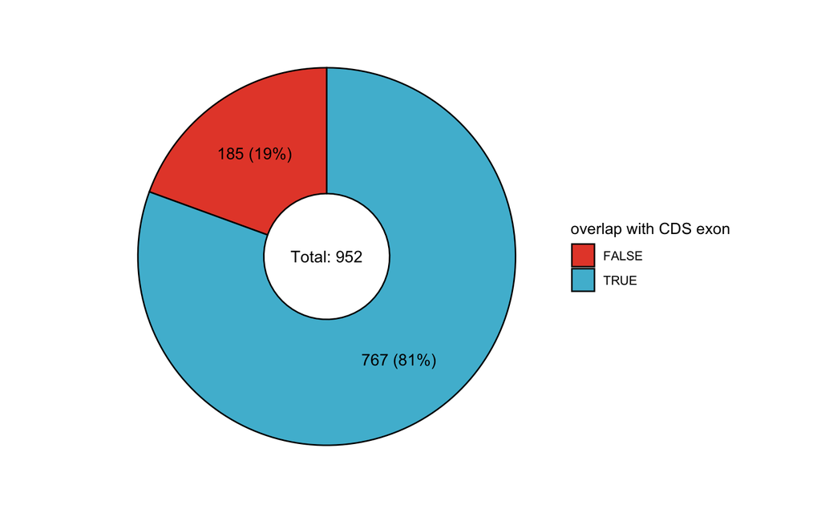

# 4 Adjusting distal/proximal exon 5’ ends

5’ ends of the upstream exons (E1D and E1P) were truncated such the phase is 0.

```r
# Adjust exon boundaries
adjustedA5SSranges <- endoapply(A5SSranges, function(gr){

    if(!gr$event_id[1] %in% phaseInfoRanges$event_id){return(GRanges())}

    #print(gr$event_id[1])

    #Get matched CDS exon
    grMatched <- phaseInfoRanges[phaseInfoRanges$event_id == gr$event_id[1]]

    #Remove nucleotides from matched CDS exon so the phase is 0
    nucleotidesToRemove <- which.max(c(mcols(grMatched)[,1], mcols(grMatched)[,2], mcols(grMatched)[,3])) - 1
    grMatched <- resize(grMatched, width = width(grMatched) - nucleotidesToRemove, fix="end")

    if(strand(gr) %>% as.character == "+" & start(gr[gr$exon == "E1D"]) <= start(grMatched)){
        start(gr[gr$exon %in% c("E1D", "E1P")]) <- start(grMatched)
    } else if(strand(gr) %>% as.character == "+" & start(gr[gr$exon == "E1D"]) > start(grMatched)){

        diff <- start(gr[gr$exon == "E1D"]) - start(grMatched)
        nucleotidesToRemove <- 3 - diff %% 3
        start(gr[gr$exon %in% c("E1D", "E1P")]) <- start(gr[gr$exon %in% c("E1D", "E1P")]) + nucleotidesToRemove

    } else if(strand(gr) %>% as.character == "-" & end(gr[gr$exon == "E1D"]) >= end(grMatched)){
        end(gr[gr$exon %in% c("E1D", "E1P")]) <- end(grMatched)
    } else if(strand(gr) %>% as.character == "-" & end(gr[gr$exon == "E1D"]) < end(grMatched)){
        diff <- end(grMatched) - end(gr[gr$exon == "E1D"])
        nucleotidesToRemove <- 3 - diff %% 3
        end(gr[gr$exon %in% c("E1D", "E1P")]) <- end(gr[gr$exon %in% c("E1D", "E1P")]) - nucleotidesToRemove
    }
    return(gr)
})
```

# 5 Inference of peptide sequences

First the nucleotide sequence of the E1D, E1P and E2 exon is extracted and subsequently E1D + E2 and E1P + E2 concatenated, followed by translation into AA sequences. If a stop codon (*) is located in the AA sequence, everything after the stop codon is removed. Peptide sequences together with additional information is stored in a data.frame.

```r
peptideDF <- lapply(adjustedA5SSranges, function(gr){

    if(length(gr) == 0){return(data.frame())}

    E1D_seq <- getSeq(Hsapiens, gr[gr$exon == "E1D"])
    E1P_seq <- getSeq(Hsapiens, gr[gr$exon == "E1P"])
    E2_seq <- getSeq(Hsapiens, gr[gr$exon == "E2"])

    E1D_E2_seq <- xscat(E1D_seq, E2_seq)
    E1P_E2_seq <- xscat(E1P_seq, E2_seq)

    E1D_E2_AAseq <- translate(E1D_E2_seq, no.init.codon=TRUE) %>% as.character  # no.init.codon=TRUE as otherwise CTG will be M instead of L
    E1P_E2_AAseq <- translate(E1P_E2_seq, no.init.codon=TRUE) %>% as.character

    hasStopCodon <- grepl("*", c(E1D_E2_AAseq, E1P_E2_AAseq), fixed=T)

    E1D_E2_AAseq <- E1D_E2_AAseq %>% strsplit(., "*", fixed=TRUE) %>% sapply("[[", 1)
    E1P_E2_AAseq <- E1P_E2_AAseq %>% strsplit(., "*", fixed=TRUE) %>% sapply("[[", 1)
    #Speichern ob Stern da war

    return(
        data.frame(
            chr = seqnames(gr[1]) %>% as.character,
            strand = strand(gr[1]) %>% as.character,
            start_E1 = start(gr[match(c("E1D", "E1P"), gr$exon)]),
            end_E1 = end(gr[match(c("E1D", "E1P"), gr$exon)]),
            start_E2 = start(gr[match("E2", gr$exon)]),
            end_E2 = end(gr[match("E2", gr$exon)]),
            event_id = gr$event_id[1],
            lsv_id = gr$lsv_id[1],
            A5SS = c("Distal", "Proximal"),
            psiCT = gr$CT_median_psi[match(c("E1D", "E1P"), gr$exon)],
            psiKD = gr$KD_median_psi[match(c("E1D", "E1P"), gr$exon)],
            dpsi = gr$KD.CT_median_dpsi[match(c("E1D", "E1P"), gr$exon)],
            event_size = gr$event_size[1],
            peptide_seq = c(E1D_E2_AAseq, E1P_E2_AAseq),
            peptide_len = c(nchar(E1D_E2_AAseq), nchar(E1P_E2_AAseq)),
            frame_shift = !(gr$event_size[match(c("E1D", "E1P"), gr$exon)] %% 3 == 0),
            stop_codon = hasStopCodon
    ))

}) %>% bind_rows()
```

# 6 Matching genes and UNIPROT entries

As the overall aim was the integration of the peptide sequences into existing SWISS-PROT entries, first the AnnotationHub package is used to access the EnsDB v105 and extract the columns GENEID, SYMBOL, UNIPROTID and UNIPROTDB.

```r
library(AnnotationHub)
ah <- AnnotationHub()

ahDb <- query(ah, pattern = c("Homo Sapiens", "EnsDb"))
ahDb_v105 <- ahDb[["AH98047"]]

keys <- peptideDF$event_id %>% strsplit(., ".", fixed=T) %>% sapply(., "[[", 1) %>% unique

mappingDF <- select(ahDb_v105, keys=keys, columns = c("SYMBOL", "UNIPROTID", "UNIPROTDB")) %>% na.omit %>% dplyr::filter(UNIPROTDB == "SWISSPROT") %>% distinct %>%
    mutate(UNIPROTID=strsplit(UNIPROTID, ".", fixed=TRUE) %>% sapply(., "[[", 1))
```

In a next step, the SWISS-PROT protein sequences (downloaded from the UNIPROT website) are loaded from a FASTA-File, placed in a data.frame and subsetted to sequences originating from a gene with a regulated A5SS event.

```r
# Load Swissprot with isoforms
uniprot <- Biostrings::readAAStringSet("/Users/mariokeller/projects/USP39/data/uniprot-compressed_true_download_true_format_fasta_includeIsoform_tr-2022.08.09-13.58.31.27.fasta")

# Turn uniprot into data.frame and add columns
uniprot <- data.frame(original_id = names(uniprot), aa_seq = uniprot %>% as.character) %>%
    mutate(isoform_id = original_id %>% strsplit(., "|", fixed=TRUE) %>% sapply(., "[[", 2)) %>%
    mutate(uniprot_id = isoform_id %>% strsplit(., "-", fixed=T) %>% sapply(., "[[", 1))

# Subset uniprot to the matched proteins
uniprot <- uniprot %>% dplyr::filter(uniprot_id %in% mappingDF$UNIPROTID)
uniprot$gene_id <- mappingDF$GENEID[match(uniprot$uniprot_id, mappingDF$UNIPROTID)]
```

# 7 Get peptide positions in SWISS-PROT sequences

To incorporate protein alterations originating from A5SS events into SWISS-PROT sequences, the in silico translated peptides are aligned against the SWISS-PROT sequences of the same gene. For this purpose, first a self-defined substitution matrix is created, which scores each mismatch by -2 and each match by 1. Next, each pair of peptides is aligned against each protein isoform using a “global-local” alignment.

Only alignments are kept where:

- both peptides have the same alignment start in the isoform sequence
- one of the peptides has a perfect match in the isoform sequence and the other peptide an internal deletion, internal insertion or a stop codon.

```r
data(BLOSUM50)

mySubMat <- BLOSUM50
mySubMat[mySubMat > -Inf] <- -2 # Maybe adjust to -3
diag(mySubMat) <- 1
colnames(mySubMat)[24] <- "U"
rownames(mySubMat)[24] <- "U"

integrationDF <- lapply(peptideDF$event_id %>% unique, function(eventID){
    A5SS_peptides <- peptideDF %>% plyranges::filter(event_id == eventID) %>% arrange(A5SS) # 2 rows
    uniprot_tmp <- uniprot %>% dplyr::filter(gene_id == eventID %>% strsplit(., ".", fixed=TRUE) %>% sapply(., "[[", 1)) # 1 or more rows

    if(nrow(uniprot_tmp) == 0){return(data.frame())} #e.g. ZNF598

    lapply(1:nrow(uniprot_tmp), function(i){
        uniprot_tmp2 <- uniprot_tmp[i,]

        pA <- pairwiseAlignment(
            pattern = A5SS_peptides %>% pull(peptide_seq) %>% AAStringSet(.), # 2
            subject = uniprot_tmp2 %>% pull(aa_seq) %>% AAStringSet(.), # 1
            substitutionMatrix = mySubMat,
            type="global-local",
            gapOpening=3, gapExtension=0.2
            )

        alignmentRes <- data.frame(event_id = eventID,
                                   lsv_id = A5SS_peptides$lsv_id,
                                   A5SS = c("Distal", "Proximal"),
                                   pattern_start = pattern(pA) %>% start,
                                   pattern_end = pattern(pA) %>% end,
                                   pattern_len = A5SS_peptides$peptide_len,
                                   uniprot_isoform_id = uniprot_tmp2$isoform_id,
                                   subject_start = subject(pA) %>% start,
                                   subject_end = subject(pA) %>% end,
                                   subject_len = uniprot_tmp2 %>% pull(aa_seq) %>% nchar,
                                   identical = c(identical(pattern(pA[1]) %>% as.character(), subject(pA[1]) %>% as.character()),
                                                 identical(pattern(pA[2]) %>% as.character(), subject(pA[2]) %>% as.character())),
                                   insertion_within = c(any(insertion(pA[1]) %>% unlist %>% end != pattern(pA[1]) %>% end),
                                                        any(insertion(pA[2]) %>% unlist %>% end != pattern(pA[2]) %>% end)),
                                   deletion_within = c(any(deletion(pA[1]) %>% unlist %>% end != pattern(pA[1]) %>% end),
                                                        any(deletion(pA[2]) %>% unlist %>% end != pattern(pA[2]) %>% end)),
                                   n_insertion = insertion(pA) %>% lengths,
                                   n_deletion = deletion(pA) %>% lengths,
                                   n_mismatch = nmismatch(pA),
                                   n_match = nmatch(pA),
                                   stop_codon = A5SS_peptides %>% pull(stop_codon)
                                   )
        # Same start in SWISSPROT sequence and pattern starts at pos 1
        if(identical(alignmentRes$subject_start[1], alignmentRes$subject_start[2]) &
           all(alignmentRes$pattern_start == 1)
           ){
            # One peptide needs perfect match
            if(any(alignmentRes$identical)){

                # In the other peptide there is an internal deletion or insertion
                if(
                    (alignmentRes$identical[1] & any(alignmentRes[2, c("insertion_within", "deletion_within")] %>% as.logical)) |
                    (alignmentRes$identical[2] & any(alignmentRes[1, c("insertion_within", "deletion_within")] %>% as.logical))
                    ){
                     alignmentRes$keep = TRUE
                # No internal deletion or insertion in other peptide
                } else {
                    # The other peptide has a stop codon
                    if(
                        (alignmentRes$identical[1] & alignmentRes$stop_codon[2]) |
                        (alignmentRes$identical[2] & alignmentRes$stop_codon[1])
                        ){

                        #Check the rare case that both are identical and the distal and the uniprot have a stop codon (should be removed)
                        if(
                            (all(alignmentRes$identical) & (!all(alignmentRes$stop_codon)) & any(alignmentRes$subject_end == alignmentRes$subject_len))
                        ){
                            alignmentRes$keep = FALSE
                        } else {
                            alignmentRes$keep = TRUE
                        }



                    # No stop codon => Either nonsens or cases where the downstream exon has two ORFs (interesting but we do not know what happens further downstream)
                    } else {
                        alignmentRes$keep = FALSE
                    }
                }
            # No peptide has a perfect match
            } else {
                alignmentRes$keep = FALSE
            }
        # Different start in SWISSPROT sequence
        } else {
            alignmentRes$keep = FALSE
            }

        return(alignmentRes)


    }) %>% bind_rows()

}) %>% bind_rows()


integrationDF <- integrationDF %>% dplyr::filter(keep)

#Add an identifier to each entry
integrationDF$newID <- paste0(integrationDF$uniprot_isoform_id, "-", integrationDF$event_id, "-", integrationDF$A5SS)

integrationDF$newID[integrationDF$identical & !integrationDF$stop_codon] <- integrationDF$uniprot_isoform_id[integrationDF$identical & !integrationDF$stop_codon]
integrationDF$newID[integrationDF$identical & integrationDF$stop_codon & (integrationDF$pattern_end == integrationDF$pattern_len) & (integrationDF$subject_end == integrationDF$subject_len)] <- integrationDF$uniprot_isoform_id[integrationDF$identical & integrationDF$stop_codon & (integrationDF$pattern_end == integrationDF$pattern_len) & (integrationDF$subject_end == integrationDF$subject_len)]
```

# 8 Integrate peptides into SWISSPROT sequences

As a penultimate step the peptide sequences are inserted into the matching SWISS-PROT isoforms.

```r
finalSequences <- lapply(1:nrow(integrationDF), function(i){

    peptide_seq <- peptideDF$peptide_seq[peptideDF$event_id == integrationDF$event_id[i] & peptideDF$A5SS == integrationDF$A5SS[i]]
    SWISSPROT_seq <- uniprot$aa_seq[uniprot$isoform_id == integrationDF$uniprot_isoform_id[i]]

    insertion_start <- integrationDF$subject_start[i]
    insertion_end <- integrationDF$subject_end[i]
    stop_codon <- integrationDF$stop_codon[i]

    if(stop_codon){
        new_SWISSPROT_seq <- paste0(substr(SWISSPROT_seq, 1, insertion_start-1), peptide_seq)
    } else {
        new_SWISSPROT_seq <- paste0(substr(SWISSPROT_seq, 1, insertion_start-1), peptide_seq, substr(SWISSPROT_seq, insertion_end+1, nchar(SWISSPROT_seq)))
    }

    data.frame(
        new_id = integrationDF$newID[i],
        event_id = integrationDF$event_id[i],
        A5SS = integrationDF$A5SS[i],
        header = paste0(c(paste0("new_id = ", integrationDF$newID[i]),
                          paste0("uniprot_isoform_id = ", integrationDF$uniprot_isoform_id[i]),
                          paste0("event_id = ", integrationDF$event_id[i]),
                          paste0("lsv_id = ", integrationDF$lsv_id[i]),
                          paste0("A5SS = ", integrationDF$A5SS[i]),
                          paste0("ct_psi = ", peptideDF$psiCT[peptideDF$event_id == integrationDF$event_id[i] & peptideDF$A5SS == integrationDF$A5SS[i]]),
                          paste0("kd_psi = " ,peptideDF$psiKD[peptideDF$event_id == integrationDF$event_id[i] & peptideDF$A5SS == integrationDF$A5SS[i]]),
                          paste0("dpsi = ", peptideDF$dpsi[peptideDF$event_id == integrationDF$event_id[i] & peptideDF$A5SS == integrationDF$A5SS[i]]),
                          paste0("frameshift = ", peptideDF$frame_shift[peptideDF$event_id == integrationDF$event_id[i] & peptideDF$A5SS == integrationDF$A5SS[i]]),
                          paste0("stop_codon = ", peptideDF$stop_codon[peptideDF$event_id == integrationDF$event_id[i] & peptideDF$A5SS == integrationDF$A5SS[i]]),
                          paste0("length_orig = ",nchar(SWISSPROT_seq)),
                          paste0("length_adj = ",nchar(new_SWISSPROT_seq))
                          ),
                        collapse=" | "),
        new_SWISSPROT_seq
    )
}) %>% bind_rows()
```

# 9 Create summary table for the A5SS events

```r
alreadyInSwissprot <- finalSequences$new_id[finalSequences$new_SWISSPROT_seq %in% uniprot$aa_seq]

#Add the dPSI
integrationDF <- left_join(integrationDF, peptideDF %>% dplyr::select(event_id, A5SS, dpsi), by = c("event_id", "A5SS"))


distalDF <- integrationDF %>% dplyr::filter(A5SS == "Distal") %>% #distalDF <- integrationDF %>% dplyr::filter(A5SS == "Distal" & !(newID %in% cleanupDF$new_id)) %>%
    mutate(inSwissprot = newID %in% alreadyInSwissprot) %>%
    group_by(event_id) %>%
    summarize(Distal = paste0(newID, collapse=","),
              Distal_inSwissprot = paste0(inSwissprot, collapse=","),
              dPSI_Distal = unique(dpsi))

proximalDF <- integrationDF %>% dplyr::filter(A5SS == "Proximal") %>% # proximalDF <- integrationDF %>% dplyr::filter(A5SS == "Proximal" & !(newID %in% cleanupDF$new_id)) %>%
    mutate(inSwissprot = newID %in% alreadyInSwissprot) %>%
    group_by(event_id) %>%
    summarize(Proximal = paste0(newID, collapse=","),
              Proximal_inSwissprot = paste0(inSwissprot, collapse=","),
              dPSI_Proximal = unique(dpsi))

summaryDF <- inner_join(distalDF, proximalDF, by = c("event_id")) %>% relocate(Proximal, .after = Distal)
summaryDF$gene_id <- summaryDF$event_id %>% strsplit(., "_", fixed=TRUE) %>% sapply(., "[[", 1)
summaryDF <- left_join(summaryDF, CDS %>% as.data.frame %>% dplyr::select(gene_id, gene_name) %>% distinct, by=c("gene_id"))

classificationDF <- readRDS("rds_files/classificationDF.rds")

summaryDF <- left_join(summaryDF, classificationDF %>% dplyr::select(event_id, group)) %>% dplyr::rename(category=group)

summaryDF <- summaryDF %>% dplyr::select(event_id, Distal, Distal_inSwissprot, dPSI_Distal, Proximal, Proximal_inSwissprot, dPSI_Proximal, gene_id, gene_name, category)
```

# 10 Write output files

In the final step the peptide sequencess as well as the adjusted SWISS-PROT isoform sequences are stored as FASTA-Files for further downstream analyses. In addition a a second summary table is stored as XLSX-File.

```r
peptideSequences <- peptideDF %>% rowwise() %>% mutate(header = paste(paste0("event_id = ", event_id),
                                                           paste0("lsv_id = ", lsv_id),
                                                           paste0("A5SS = ", A5SS),
                                                           paste0("ct_psi = ", psiCT),
                                                           paste0("kd_psi = " , psiKD),
                                                           paste0("dpsi = ", dpsi),
                                                           paste0("frameshift = ", frame_shift),
                                                           paste0("stop_codon = ", stop_codon),
                                                           paste0("peptide_len = ", peptide_len),
                                                         sep = " | "))

peptideSequences <- Biostrings::AAStringSet(peptideSequences$peptide_seq) %>% setNames(., peptideSequences$header)
writeXStringSet(peptideSequences, "fasta_files/petptide_sequences.fasta")


#regulation to new_id

reg_to_new_id <- rbind(
    summaryDF %>%
        dplyr::select(Distal, dPSI_Distal, event_id) %>%
        mutate(reg = ifelse(dPSI_Distal > 0, "up", "down"),
               A5SS = "Distal") %>%
        separate_rows(., 1, sep=",") %>%
        dplyr::rename(new_id = Distal) %>%
        dplyr::select(new_id, reg, event_id, A5SS),
    summaryDF %>%
        dplyr::select(Proximal, dPSI_Proximal, event_id) %>%
        mutate(reg = ifelse(dPSI_Proximal > 0, "up", "down"),
               A5SS = "Proximal") %>%
        separate_rows(., 1, sep=",") %>%
        dplyr::rename(new_id = Proximal) %>%
        dplyr::select(new_id, reg, event_id, A5SS)
)

finalSequences <- left_join(finalSequences, reg_to_new_id, by=c("new_id", "event_id", "A5SS"))

finalSequences <- finalSequences %>% dplyr::filter(!is.na(reg))

upFASTA <- finalSequences %>% dplyr::filter(reg == "up")
upFASTA <- Biostrings::AAStringSet(upFASTA$new_SWISSPROT_seq) %>% setNames(., upFASTA$header)
writeXStringSet(upFASTA, "fasta_files/upregulated_isoforms.fasta")

downFASTA <- finalSequences %>% dplyr::filter(reg == "down")
downFASTA <- Biostrings::AAStringSet(downFASTA$new_SWISSPROT_seq) %>% setNames(., downFASTA$header)
writeXStringSet(downFASTA, "fasta_files/downregulated_isoforms.fasta")

regulatedFASTA <- Biostrings::AAStringSet(finalSequences$new_SWISSPROT_seq) %>% setNames(., finalSequences$header)
writeXStringSet(regulatedFASTA, "fasta_files/regulated_isoforms.fasta")

xlsx::write.xlsx2(summaryDF %>% as.data.frame, "xlsx_files/summary_A5SS_adjusted_Swissprot_sequences.xlsx", row.names=FALSE)


# Files for FAS analysis
fasDF <- summaryDF %>% dplyr::select(event_id, Distal, Proximal) %>% separate_rows(., 2:3, sep = ",")

fasDF <- fasDF %>%
    mutate(A5SS = "Distal") %>%
    dplyr::rename(new_id = Distal) %>%
    left_join(., finalSequences %>% dplyr::select(new_id, event_id, A5SS, header), by = c("new_id", "event_id", "A5SS")) %>%
    dplyr::rename(Distal = new_id, Distal_header = header) %>%
    mutate(A5SS = "Proximal") %>%
    dplyr::rename(new_id = Proximal) %>%
    left_join(., finalSequences %>% dplyr::select(new_id, event_id, A5SS, header), by = c("new_id", "event_id", "A5SS")) %>%
    dplyr::rename(Proximal = new_id, Proximal_header = header) %>%
    dplyr::select(Distal_header, Proximal_header)

write.table(fasDF, "tsv_files/FAS_pairing.tsv", col.names=TRUE, row.names = FALSE, sep="\t", quote=FALSE)
```